# R Code Corresponding to the Book *Publication Bias in Meta-Analysis* by Rothstein et al. (2005)

Wolfgang Viechtbauer Maastricht University

01 October, 2023

## General Notes / Setup

The book *Publication Bias in Meta-Analysis: Prevention, Assessment and Adjustments* by Rothstein et al. (2005) provides a very comprehensive treatment of the topic of publication bias. In this document, I provide the R code to reproduce the worked examples and analyses from various chapters. Emphasis will be on using the `metafor` package, but a few other packages will also be used. To read more about the `metafor` package, see the [package website](https://www.metafor-project.org/) and the [package documentation](https://wviechtb.github.io/metafor/).

The package can be installed with:

```r
install.packages("metafor")
```

Once the package is installed, we can load it with:

```r
library(metafor)
```

A few additional notes:

1. Results are only reproduced for chapters containing worked examples.
2. Occasionally, there are some minor discrepancies between the results shown in the book and those obtained below. These can result from using different software packages that implement methods in slightly different ways, due to intermittent rounding or using a different rounding scheme, or due to chance when the analyses involve some stochastic process. Minor discrepancies will (usually) not be commented on. However, where discrepancies are more substantial, they will be noted (and the reasons for them if they are known).
3. The results are generally given without discussion or context. The code below is not a substitute for reading the book, but is meant to be used together with it. In other words, readers of the book interested in replicating the results with R can see here how this is possible.

## Appendix A: Data Sets

We will actually start with Appendix A, which provides the three datasets used throughout the book for illustrative purposes.

### Dataset 1

```r
# data for the meta-analysis on teacher expectancy effects

dat1 <- dat.raudenbush1985
dat1$vi <- c(0.126, 0.147, 0.167, 0.397, 0.371, 0.103, 0.103, 0.221, 0.165, 0.260,
             0.307, 0.223, 0.289, 0.291, 0.159, 0.167, 0.139, 0.094, 0.174)^2
dat1$weeks <- ifelse(dat1$weeks > 1, 1, 0) # dummy-code weeks variable into 'high' vs 'low'
dat1
```

```
##    study               author year weeks setting tester n1i n2i      yi     vi
## 1      1     Rosenthal et al. 1974     1   group  aware  77 339  0.0300 0.0159
## 2      2          Conn et al. 1968     1   group  aware  60 198  0.1200 0.0216
## 3      3          Jose & Cody 1971     1   group  aware  72  72 -0.1400 0.0279
## 4      4   Pellegrini & Hicks 1972     0   group  aware  11  22  1.1800 0.1576
## 5      5   Pellegrini & Hicks 1972     0   group  blind  11  22  0.2600 0.1376
## 6      6    Evans & Rosenthal 1969     1   group  aware 129 348 -0.0600 0.0106
## 7      7       Fielder et al. 1971     1   group  blind 110 636 -0.0200 0.0106
## 8      8             Claiborn 1969     1   group  aware  26  99 -0.3200 0.0488
## 9      9               Kester 1969     0   group  aware  75  74  0.2700 0.0272
## 10    10              Maxwell 1970     0   indiv  blind  32  32  0.8000 0.0676
## 11    11               Carter 1970     0   group  blind  22  22  0.5400 0.0942
## 12    12              Flowers 1966     0   group  blind  43  38  0.1800 0.0497
## 13    13              Keshock 1970     0   indiv  blind  24  24 -0.0200 0.0835
## 14    14            Henrikson 1970     1   indiv  blind  19  32  0.2300 0.0847
## 15    15                 Fine 1972     1   group  aware  80  79 -0.1800 0.0253
## 16    16              Grieger 1970     1   group  blind  72  72 -0.0600 0.0279
## 17    17 Rosenthal & Jacobson 1968     0   group  aware  65 255  0.3000 0.0193
## 18    18   Fleming & Anttonen 1971     1   group  blind 233 224  0.0700 0.0088
## 19    19             Ginsburg 1970     1   group  aware  65  67 -0.0700 0.0303
```

```r
# note: 'yi' are the standardized mean differences and 'vi' the corresponding sampling variances;
# the sampling variances in 'dat.raudenbush1985' were computed in a slightly different way than in
# the dataset included in the book, so to make sure we can obtain the same results as provided in
# the book, we just overwrite 'vi' with the squared standard errors given in Table A.1
```

```r
# equal-effects model for studies where teachers had more than one week of contact with the students

res.h <- rma(yi, vi, data=dat1, subset=weeks==1, method="EE", digits=2)
res.h
```

```
## Equal-Effects Model (k = 11)
##
## I^2 (total heterogeneity / total variability):   0.00%
## H^2 (total variability / sampling variability):  0.64
##
## Test for Heterogeneity:
## Q(df = 10) = 6.38, p-val = 0.78
##
## Model Results:
##
## estimate    se   zval  pval  ci.lb  ci.ub
##    -0.02  0.04  -0.52  0.60  -0.10   0.06
##
## ---
## Signif. codes:  0 '***' 0.001 '**' 0.01 '*' 0.05 '.' 0.1 ' ' 1
```

```r
# equal-effects model for studies where teachers had a week or less of contact with the students

res.l <- rma(yi, vi, data=dat1, subset=weeks==0, method="EE", digits=2)
res.l
```

```
## Equal-Effects Model (k = 8)
##
## I^2 (total heterogeneity / total variability):   32.65%
## H^2 (total variability / sampling variability):  1.48
##
## Test for Heterogeneity:
## Q(df = 7) = 10.39, p-val = 0.17
##
## Model Results:
##
## estimate    se  zval  pval  ci.lb  ci.ub
##     0.35  0.08  4.41  <.01   0.19   0.50  ***
##
## ---
## Signif. codes:  0 '***' 0.001 '**' 0.01 '*' 0.05 '.' 0.1 ' ' 1
```

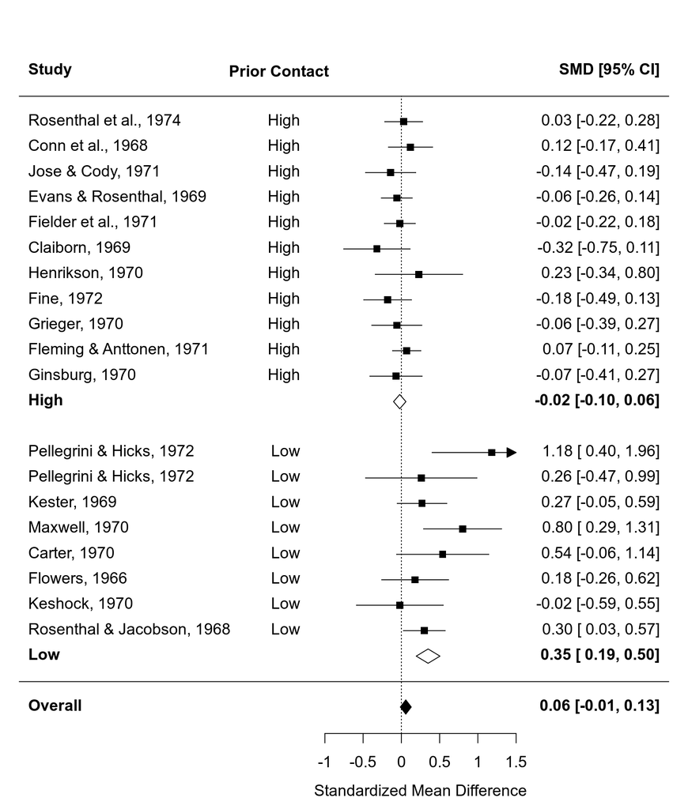

```r
# Figure A.1

par(mar=c(4,4,2,2))

tmp <- rbind(dat1[dat1$weeks == 1,], dat1[dat1$weeks == 0,])
tmp$weeks <- ifelse(tmp$weeks == 1, "High", "Low")

with(tmp, forest(yi, vi, slab=paste0(author, ", ", year), psize=1, efac=c(0,1),
       xlim=c(-5, 3.5), ylim=c(-1,25), header=TRUE, at=seq(-1,1.5,by=0.5),
       rows=c(22:12, 9:2), ilab=weeks, ilab.xpos=-1.2, ilab.pos=2))

text(-1.6, 24, "Prior Contact", font=2)

addpoly(res.h, row=11, mlab="High", col="white", font=c(sans=2))
addpoly(res.l, row= 1, mlab="Low",  col="white", font=c(sans=2))

res <- rma(yi, vi, data=tmp, method="EE")
addpoly(res, row=-1, mlab="Overall", font=c(sans=2))
abline(h=0)
```

### Dataset 2

```r
# data for the meta-analysis on the effect of environmental tobacco smoke on lung cancer risk

dat2 <- dat.hackshaw1998
head(dat2, 10) # show the first 10 rows
```

```
##    study       author year   country       design cases   or or.lb or.ub      yi     vi
## 1      1    Garfinkel 1981       USA       cohort   153 1.18  0.90  1.54  0.1655 0.0188
## 2      2     Hirayama 1984     Japan       cohort   200 1.45  1.02  2.08  0.3716 0.0330
## 3      3       Butler 1988       USA       cohort     8 2.02  0.48  8.56  0.7031 0.5402
## 4      4     Cardenas 1997       USA       cohort   150 1.20  0.80  1.60  0.1823 0.0313
## 5      5         Chan 1982 Hong Kong case-control    84 0.75  0.43  1.30 -0.2877 0.0797
## 6      6       Correa 1983       USA case-control    22 2.07  0.81  5.25  0.7275 0.2273
## 7      7 Trichopolous 1983    Greece case-control    62 2.13  1.19  3.83  0.7561 0.0889
## 8      8      Buffler 1984       USA case-control    41 0.80  0.34  1.90 -0.2231 0.1927
## 9      9        Kabat 1984       USA case-control    24 0.79  0.25  2.45 -0.2357 0.3390
## 10    10          Lam 1985 Hong Kong case-control    60 2.01  1.09  3.72  0.6981 0.0981
```

```r
# note: 'yi' are the log odds ratios and 'vi' the corresponding sampling variances; the studies in
# 'dat.hackshaw1998' are ordered by their publication year and hence are not in the same order as in
# Figure A.2, but this is (with some minor rounding discrepancies) the same dataset; also note that
# the 'yi' values are in some chapters referred to as log risk ratios
```

```r
# random-effects model

res <- rma(yi, vi, data=dat2, method="DL", digits=2, slab=paste0(author, ", ", year))
predict(res, transf=exp)
```

```
##  pred ci.lb ci.ub pi.lb pi.ub
##  1.24  1.13  1.36  0.94  1.63
```

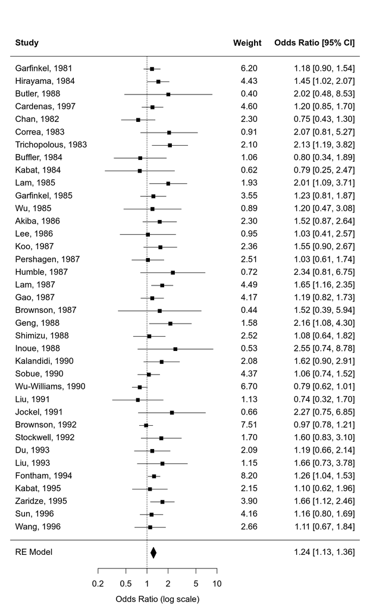

```r
# Figure A.2

par(mar=c(4,4,2,2))

wi <- fmtx(weights(res), digits=2)

forest(res, atransf=exp, psize=1, header=TRUE, xlim=c(-4.5,7), ylim=c(-0.6,40),
       at=log(c(0.2, 0.5, 1, 2, 5, 10)), efac=c(0,1),
       ilab=wi, ilab.xpos=3.8, ilab.pos=2)
text(3.3, 39, "Weight", font=2)
```

### Dataset 3

```r
# data for the meta-analysis on employment interview scores and job performance

dat3 <- dat.mcdaniel1994
dat3r <- escalc(measure="COR", ri=ri, ni=ni, data=dat3)
dat3z <- escalc(measure="ZCOR", ri=ri, ni=ni, data=dat3)
head(dat3r, 10) # show the first 10 rows
```

```
##    study   ni   ri type struct     yi     vi
## 1      1  123 0.00    j      s 0.0000 0.0082
## 2      2   95 0.06    p      u 0.0600 0.0106
## 3      3   69 0.36    j      s 0.3600 0.0111
## 4      4 1832 0.15    j      s 0.1500 0.0005
## 5      5   78 0.14    j      s 0.1400 0.0125
## 6      6  329 0.06    j      s 0.0600 0.0030
## 7      7  153 0.09    j      s 0.0900 0.0065
## 8      8   29 0.40    j      s 0.4000 0.0252
## 9      9   29 0.39    s      s 0.3900 0.0257
## 10    10  157 0.14    s      s 0.1400 0.0062
```

```r
# note: in 'dat3r', 'yi' are the raw correlation coefficients and 'vi' the corresponding sampling
# variances; in 'dat3z', 'yi' are the r-to-z transformed correlation coefficients and 'vi' the
# corresponding sampling variances
```

```r
# random-effects model

res <- rma(yi, vi, data=dat3z, digits=2, method="DL")
predict(res, transf=transf.ztor)
```

```
##  pred ci.lb ci.ub pi.lb pi.ub
##  0.23  0.20  0.26 -0.09  0.51
```

```r
# fit random-effects models for the various subgroups

res.s <- rma(yi, vi, method="DL", data=dat3z, subset=struct=="s")
res.u <- rma(yi, vi, method="DL", data=dat3z, subset=struct=="u")
res.j <- rma(yi, vi, method="DL", data=dat3z, subset=type=="j" | type=="s")
res.p <- rma(yi, vi, method="DL", data=dat3z, subset=type=="p")
```

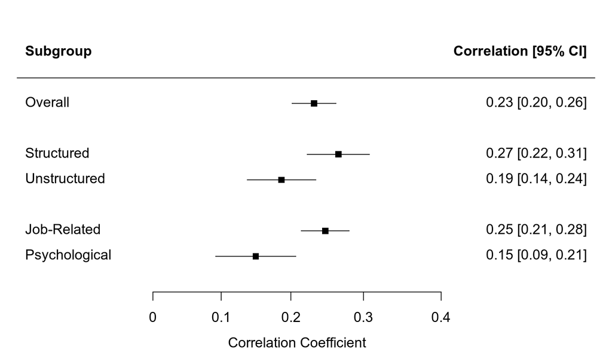

```r
# Figure A.3

par(mar=c(4,4,2,2))

yi <- c(coef(res), coef(res.s), coef(res.u), coef(res.j), coef(res.p))
vi <- c(vcov(res), vcov(res.s), vcov(res.u), vcov(res.j), vcov(res.p))
slab <- c("Overall", "Structured", "Unstructured", "Job-Related", "Psychological")
forest(yi, vi, slab=slab, xlim=c(-0.2,0.65), ylim=c(0,10),
       atransf=transf.ztor, at=transf.rtoz(c(0,0.1,0.2,0.3,0.4)),
       xlab="Correlation Coefficient", header=c("Subgroup", "Correlation [95% CI]"),
       refline=NA, efac=0, psize=1, rows=c(7, 5:4, 2:1))
```

## 5) The Funnel Plot

```r
# data for the meta-analysis on magnesium treatment in the prevention of death following MI

dat <- dat.egger2001

# calculate log odds ratios and corresponding sampling variances

dat <- escalc(measure="OR", ai=ai, n1i=n1i, ci=ci, n2i=n2i, data=dat)
dat
```

```
##    id        study year   ai   n1i   ci   n2i      yi     vi
## 1   1       Morton 1984    1    40    2    36 -0.8303 1.5551
## 2   2    Rasmussen 1986    9   135   23   135 -1.0561 0.1715
## 3   3        Smith 1986    2   200    7   200 -1.2783 0.6531
## 4   4      Abraham 1987    1    48    1    46 -0.0435 2.0435
## 5   5    Feldstedt 1988   10   150    8   148  0.2231 0.2393
## 6   6     Shechter 1989    1    59    9    56 -2.4075 1.1496
## 7   7 Ceremuzynski 1989    1    25    3    23 -1.2809 1.4250
## 8   8    Bertschat 1989    0    22    1    21 -1.1917 2.7599
## 9   9        Singh 1990    6    76   11    75 -0.6957 0.2875
## 10 10      Pereira 1990    1    27    7    27 -2.2083 1.2313
## 11 11     Shechter 1991    2    89   12    80 -2.0382 0.6095
## 12 12         Golf 1991    5    23   13    33 -0.8502 0.3825
## 13 13    Thogersen 1991    4   130    8   122 -0.7932 0.3917
## 14 14      LIMIT-2 1992   90  1159  118  1157 -0.2993 0.0215
## 15 15     Shechter 1995    4   107   17   108 -1.5708 0.3295
## 16 16       ISIS-4 1995 2216 29011 2103 29039  0.0576 0.0010
```

```r
# fit an equal-effects model

res <- rma(yi, vi, data=dat, method="EE", digits=3)
res
```

```
## Equal-Effects Model (k = 16)
##
## I^2 (total heterogeneity / total variability):   68.13%
## H^2 (total variability / sampling variability):  3.14
##
## Test for Heterogeneity:
## Q(df = 15) = 47.059, p-val < .001
##
## Model Results:
##
## estimate     se   zval   pval   ci.lb  ci.ub
##    0.015  0.031  0.484  0.629  -0.045  0.075
##
## ---
## Signif. codes:  0 '***' 0.001 '**' 0.01 '*' 0.05 '.' 0.1 ' ' 1
```

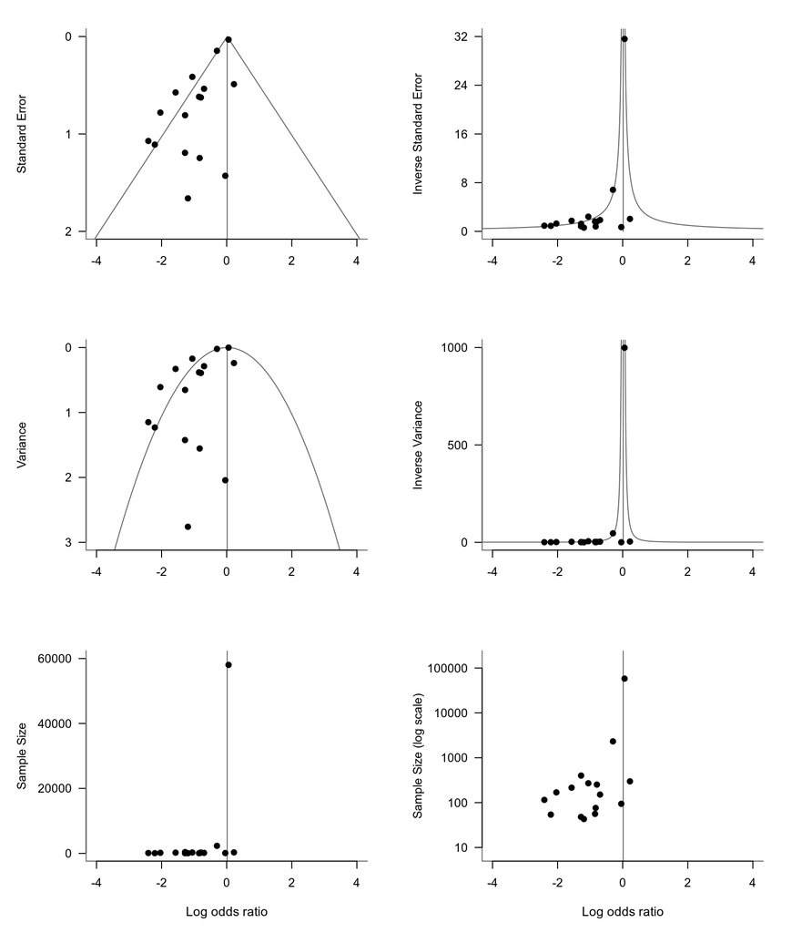

```r
# Figure 5.6: Funnel plots for the magnesium trials with different vertical axes

par(mfrow=c(3,2), mar=c(5,6,2,2), mgp=c(4,1,0), las=1)

funnel(res, yaxis="sei",   xlim=c(-4,4), ylim=c(0,2),       steps=3, back=NA, lty=1, xlab="")
funnel(res, yaxis="seinv", xlim=c(-4,4), ylim=c(1e-6,32),            back=NA, lty=1, xlab="")
funnel(res, yaxis="vi",    xlim=c(-4,4), ylim=c(0,3),       steps=4, back=NA, lty=1, xlab="")
funnel(res, yaxis="vinv",  xlim=c(-4,4), ylim=c(1e-6,1000), steps=3, back=NA, lty=1, xlab="")
funnel(res, yaxis="ni",    xlim=c(-4,4), ylim=c(0,60000),   steps=4, back=NA, lty=1, xlab="")
mtext("Log odds ratio", side=1, line=3, cex=0.7)
funnel(res, yaxis="lni",   xlim=c(-4,4), ylim=c(2,12),      steps=6, back=NA, lty=1, xlab="",
       yaxt="n", ylab="Sample Size (log scale)")
axis(side=2, at=log(c(10, 100, 1000, 10000, 100000)),
     labels=c("10", "100", "1000", "10000", "100000"))
mtext("Log odds ratio", side=1, line=3, cex=0.7)
```

```r
# fit an equal-effects model to dataset 2

res <- rma(yi, vi, data=dat2, method="EE")
res
```

```
## Equal-Effects Model (k = 37)
##
## I^2 (total heterogeneity / total variability):   24.21%
## H^2 (total variability / sampling variability):  1.32
##
## Test for Heterogeneity:
## Q(df = 36) = 47.4979, p-val = 0.0952
##
## Model Results:
##
## estimate      se    zval    pval   ci.lb   ci.ub
##   0.1858  0.0373  4.9797  <.0001  0.1126  0.2589  ***
##
## ---
## Signif. codes:  0 '***' 0.001 '**' 0.01 '*' 0.05 '.' 0.1 ' ' 1
```

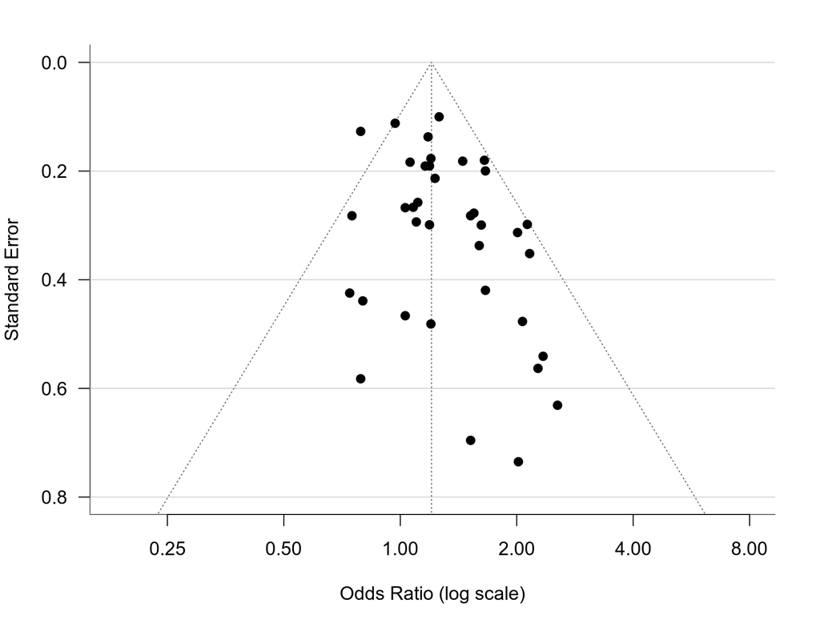

```r
# Figure 5.7

par(mar=c(5,4,2,2))

funnel(res, atransf=exp, at=log(c(0.25,0.50,1,2,4,8)), ylim=c(0,0.8), las=1, digits=c(2,1),
       back=NA, shade=NA, hlines="lightgray")
```

```r
# fit an equal-effects model to dataset 1

res <- rma(yi, vi, data=dat1, method="EE")
res
```

```
## Equal-Effects Model (k = 19)
##
## I^2 (total heterogeneity / total variability):   47.12%
## H^2 (total variability / sampling variability):  1.89
##
## Test for Heterogeneity:
## Q(df = 18) = 34.0384, p-val = 0.0125
##
## Model Results:
##
## estimate      se    zval    pval    ci.lb   ci.ub
##   0.0578  0.0366  1.5786  0.1144  -0.0140  0.1295
##
## ---
## Signif. codes:  0 '***' 0.001 '**' 0.01 '*' 0.05 '.' 0.1 ' ' 1
```

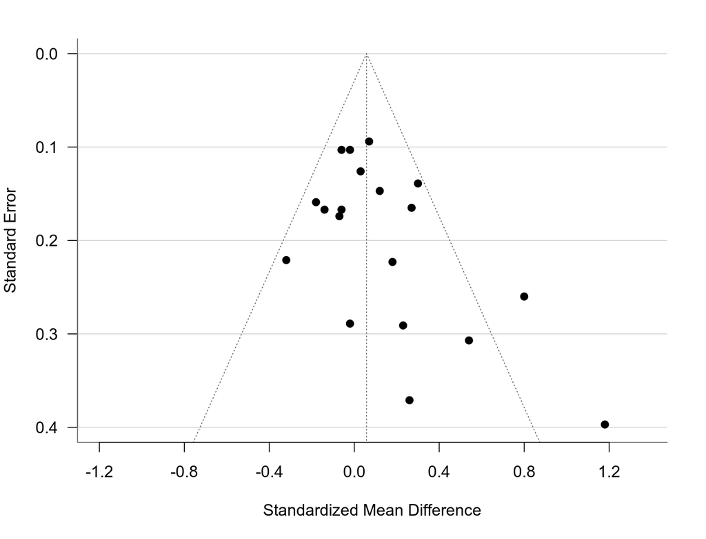

```r
# Figure 5.8a

par(mar=c(5,4,2,2))

funnel(res, at=seq(-1.2,1.2,by=0.4), ylim=c(0,0.4), las=1, digits=1,
       back=NA, shade=NA, hlines="lightgray")
```

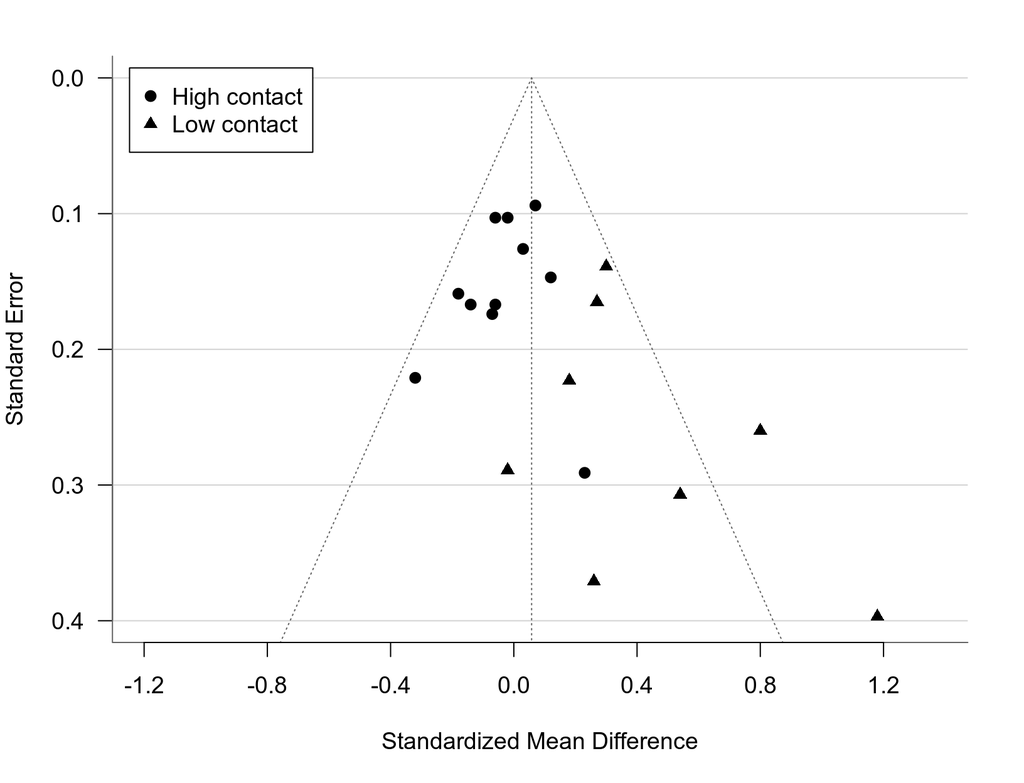

```r
# Figure 5.8b

par(mar=c(5,4,2,2))

funnel(res, at=seq(-1.2,1.2,by=0.4), ylim=c(0,0.4), las=1, digits=c(1,1),
       back=NA, shade=NA, hlines="lightgray", pch=ifelse(weeks == 1, 19, 17))
legend("topleft", inset=0.02, bg="white", pch=c(19,17), legend=c("High contact", "Low contact"))
```

```r
# fit an equal-effects model to dataset 3r

res <- rma(yi, vi, data=dat3r, method="EE")
res
```

```
## Equal-Effects Model (k = 160)
##
## I^2 (total heterogeneity / total variability):   97.41%
## H^2 (total variability / sampling variability):  38.60
##
## Test for Heterogeneity:
## Q(df = 159) = 6136.9194, p-val < .0001
##
## Model Results:
##
## estimate      se     zval    pval   ci.lb   ci.ub
##   0.4713  0.0048  97.9829  <.0001  0.4619  0.4808  ***
##
## ---
## Signif. codes:  0 '***' 0.001 '**' 0.01 '*' 0.05 '.' 0.1 ' ' 1
```